# Visualizing disease-disease associations

2016-09-29

In the last post, we went through the process of simulating some random billing claims data, then putting it through the CSPADE algorithm to see if there were any interesting frequent sequences. Here, we’ll review how to graph association rules without sequences.

Before we begin any coding, I’d like to point out that our model will involve considering patients as transactions, and diseases as items. There are also several metrics for evaluating associations; for more on understanding association rules, [check out the `arules` package author’s document.](https://cran.r-project.org/web/packages/arules/vignettes/arules.pdf) It’s a great website, and I highly recommend reading through it.

### Load libraries, get data

First, of course, we’ll have to load some libraries.

```
library(arules)
library(arulesViz)
library(dplyr)
library(ggplot2)
library(tidyr)
library(stringr)
```

Because this is a simulation, there will be some randomness involved. To make sure you can replicate everything, we’ll set a seed:

```
set.seed(9001)
```

To begin making data, here’s a list of diseases. We’ll use that to make a dataframe with five patients.

```
diseases <-
    c("Heart_disease",
      "Hypertension",
      "Kidney_disease",
      "Liver_cirrhosis",
      "Gall_stones",
      "Kidney_stones",
      "Tonsiliths",
      "Unspecified_cancer",
      "Vitamin_D_deficiency",
      "Trichtillomania",
      "Hearing_loss")

claims_data <-
    data.frame(disease = sample(diseases, 20, replace = TRUE),
           patient = rep_len(1:5, 20), stringsAsFactors = FALSE)
```

### Format data for arules

Given some data, let’s prepare it for associations analysis. We’ll use the `split` command to produce a list of the diseases that contains a vector of patient identifiers for patients with those diseases.

Here we go:

```
claims_tx <- split(claims_data$patient, claims_data$disease)
```

I’ll be artificially adding “Hypertension” and “Kidney disease” to several of the patients, just to make sure arules works. ;)

```
claims_tx$Hypertension <- c(claims_tx$Hypertension, 1:3)

claims_tx$Kidney_disease <- c(claims_tx$Kidney_disease, 1:3)

claims_tx$Heart_disease <- c(claims_tx$Heart_disease, 1:3)
```

Hopefully that will work..

Note that `arules` won’t accept “tidLists” with a transaction listed more than once. In our case, that means that patients who have several of the same diagnosis will be considered only in terms of their yes-no disease status. If you’re interested in recommender systems that can handle ratings or counts data, I recommend looking into [collaborative filtering approaches](https://en.wikipedia.org/wiki/Netflix_Prize).

```
claims_tx <- lapply(claims_tx, function(x) sort(unique(x)))

claims_tx <- as(claims_tx, "tidLists")
```

### Checking out our data

Even before running the *apriori* or *eclat* algorithms, there’s a lot to learn about the data.

Here’s what R shows when you ask for the object:

```
claims_tx

## tidLists in sparse format with
##  10 items/itemsets (rows) and
##  5 transactions (columns)
```

That’s useful–we know how many items (diagnoses) and how many transactions (patients) we have.

We can also `inspect` the claims:

```
claims_inspect <- inspect(claims_tx)
```

| items | transactionIDs |
| --- | --- |
| Hearing_loss | {2,3,4} |
| Heart_disease | {1,2,3,5} |
| Hypertension | {1,2,3,5} |
| Kidney_disease | {1,2,3} |
| Kidney_stones | {2} |
| Liver_cirrhosis | {3} |
| Tonsiliths | {4} |
| Trichtillomania | {1,2,3} |
| Unspecified_cancer | {4,5} |
| Vitamin_D_deficiency | {5} |

The previous table tells us which patients have which diseases. There are a few ways to interpret this, as far as extracting interesting information.

For a more extensive list of things to do with `tidLists`, we can use the `methods` function:

```
methods(class = "tidLists")

##  [1] abbreviate        coerce            c
##  [4] dimnames<-        dimnames          dim
##  [7] image             initialize        inspect
## [10] itemFrequency     itemInfo<-        itemInfo
## [13] itemLabels        labels            length
## [16] LIST              show              size
## [19] summary           [                 transactionInfo<-
## [22] transactionInfo   t
## see '?methods' for accessing help and source code
```

The last exploration we’ll do before association analyses is a visualization:

```
image(claims_tx)
```

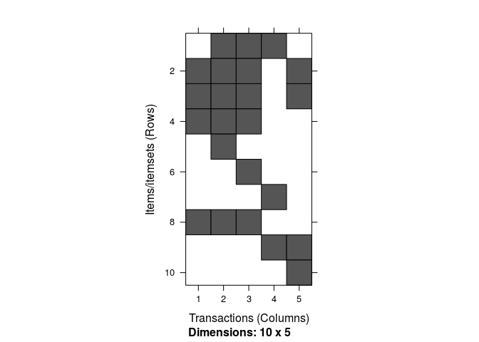

### `arules` and friends

At this point, let’s see what the *apriori* algorithm has to say. First, we’ll have R calculate the relationships according to our own parameters: minimum support, minimum confidence and the maximum length of an association.

```
claims_rules <-
  apriori(claims_tx, parameter = list(support = 0.01, confidence = 0.1, maxlen = 2))

## Apriori
##
## Parameter specification:
##  confidence minval smax arem  aval originalSupport maxtime support minlen
##         0.1    0.1    1 none FALSE            TRUE       5    0.01      1
##  maxlen target   ext
##       2  rules FALSE
##
## Algorithmic control:
##  filter tree heap memopt load sort verbose
##     0.1 TRUE TRUE  FALSE TRUE    2    TRUE
##
## Absolute minimum support count: 0
##
## set item appearances ...[0 item(s)] done [0.00s].
## set transactions ...[10 item(s), 5 transaction(s)] done [0.00s].
## sorting and recoding items ... [10 item(s)] done [0.00s].
## creating transaction tree ... done [0.00s].
## checking subsets of size 1 2 done [0.00s].
## writing ... [66 rule(s)] done [0.00s].
## creating S4 object  ... done [0.00s].
```

There are a few packages for rules visualization, it’s worth going through `rules` class methods before getting our hands dirty with the raw data:

```
methods(class = "rules")

##  [1] abbreviate             aggregate              coerce
##  [4] coverage               c                      dissimilarity
##  [7] duplicated             generatingItemsets     head
## [10] %in%                   info<-                 info
## [13] initialize             inspectDT              inspect
## [16] interestMeasure        intersect              is.element
## [19] is.maximal             is.redundant           is.significant
## [22] is.subset              is.superset            itemInfo
## [25] itemLabels             items                  labels
## [28] length                 lhs<-                  lhs
## [31] match                  plot                   quality<-
## [34] quality                rhs<-                  rhs
## [37] [                      sample                 setdiff
## [40] setequal               show                   size
## [43] sort                   subset                 summary
## [46] support                supportingTransactions tail
## [49] t                      union                  unique
## [52] write
## see '?methods' for accessing help and source code
```

There’s a lot available to explore!

### An aside: beyond support

This is healthcare data, so it makes the sense to look at tests of difference and odds ratios. There are other measures of rules, definitely check out the documentation.

Here’s how to calculate the interest measures and cbind them to a data frame showing associations and other measures:

```
claims_rules_measures <- interestMeasure(x = claims_rules,
                                         measure = c("chiSquared", "FishersExactTest", "oddsRatio"),
                                         transactions = claims_tx)

claims_rules_measures <-
  cbind(as(claims_rules, "data.frame"), claims_rules_measures)
```

There’s some munging required, mostly just splitting the 1 -> 2 rule variable into two variables.

```
library(statnet)

claims_rules_measures$rules <- as.character(claims_rules_measures$rules)

claims_rules_measures <-
  claims_rules_measures %>%
    separate(col = "rules",
           into = c("First_disease", "Second_disease"),
           sep = "\\=\\>",
           extra = "drop")

claims_rules_measures$First_disease <-
  str_replace_all(string = claims_rules_measures$First_disease,
                  pattern = "\\{|\\}", replacement = "") %>%
  str_trim(side = "both")

claims_rules_measures$Second_disease <-
  str_replace_all(string = claims_rules_measures$Second_disease,
                  pattern = "\\{|\\}", replacement = "") %>%
  str_trim(side = "both")

claims_rules_measures <-
  claims_rules_measures %>% filter(First_disease != "")

claims_rules_measures <-
  claims_rules_measures[rep_len(c(TRUE, FALSE), nrow(claims_rules_measures)),]
```

### Visualization

To get going, here’s one of the default plotting methods:

```
plot(claims_rules, method = "graph", control = list(type = "items"))
```

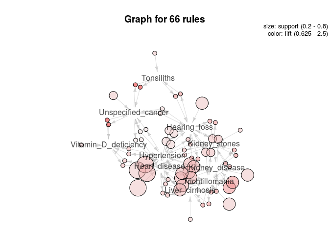

We can also use the `claims_rules_measures` data to make a network of disease-disease associations:

```
claims_network <-
  network(x = cbind(claims_rules_measures$First_disease, claims_rules_measures$Second_disease), directed = TRUE)
```

Let’s see what this `network` object looks like:

```
plot(claims_network)
```

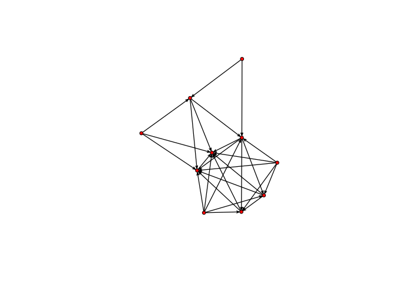

Or, we can try doing something like this with igraph:

```
library(igraph)

claims_igraph <- graph.data.frame(d = claims_rules_measures %>% select(First_disease, Second_disease, oddsRatio))

plot(claims_igraph, edge.arrow.size = 0.04)
```

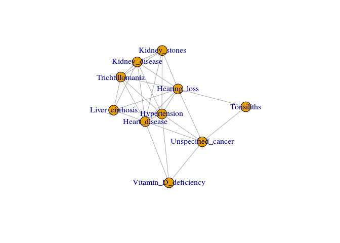

```
class(claims_igraph)

## [1] "igraph"

methods(class = "igraph")

##  [1] cohesion     difference   -            [<-          [
##  [6] [[           $<-          $            *            +
## [11] intersection modularity   plot         print        rep
## [16] rglplot      scg          str          summary      union
## see '?methods' for accessing help and source code
```

We can even use `ggplot2`:

```
library(ggnetwork)

library(viridis)


claims_ggnetwork <- ggnetwork(claims_network)

claims_ggnetwork$vertex.names <- as.character(claims_ggnetwork$vertex.names)


ggplot(claims_ggnetwork, aes()) +
  geom_segment(aes(x = x, y = y, xend = xend, yend = yend)) +
  geom_point(aes(x, y, col = vertex.names), size = 10) +
  scale_color_viridis(discrete = TRUE) +
  theme(legend.position = "right")
```

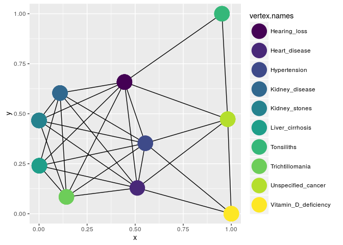

Hopefully, it’s pretty clear which nodes represent the diseases whose incidence was artificially increased (even without a legend).

## To come….

- Adding interesting attributes to the graphs from this post
- Network analysis with `rules` objects
- Getting started with SEER data in R
- Analyzing time to second cancer using SEER